# ISLR - Chapter 5 Resampling Methods: Applied Exercises

Chee Loong Lian

12/26/2017

**Q5(a) Fit a logistic regression model that uses “income” and “balance” to predict “default” on the “Default” data set.**

```r
library(ISLR)
attach(Default)
set.seed(1)
glm.fit <- glm(default ~ income + balance, data = Default, family = "binomial")
summary(glm.fit)
```

```
##
## Call:
## glm(formula = default ~ income + balance, family = "binomial",
##     data = Default)
##
## Deviance Residuals:
##     Min       1Q   Median       3Q      Max
## -2.4725  -0.1444  -0.0574  -0.0211   3.7245
##
## Coefficients:
##               Estimate Std. Error z value Pr(>|z|)
## (Intercept) -1.154e+01  4.348e-01 -26.545  < 2e-16 ***
## income       2.081e-05  4.985e-06   4.174 2.99e-05 ***
## balance      5.647e-03  2.274e-04  24.836  < 2e-16 ***
## ---
## Signif. codes:  0 '***' 0.001 '**' 0.01 '*' 0.05 '.' 0.1 ' ' 1
##
## (Dispersion parameter for binomial family taken to be 1)
##
##     Null deviance: 2920.6  on 9999  degrees of freedom
## Residual deviance: 1579.0  on 9997  degrees of freedom
## AIC: 1585
##
## Number of Fisher Scoring iterations: 8
```

**(b) Using the validation set approach, estimate the test error of this model.**

1. Split the sample set into a training set and a validation set.

```r
train <- sample(dim(Default)[1], dim(Default)[1] / 2)
Default.test <- Default[-train, ]
default.test <- default[-train]
```

2. Fit a multiple logistic regression model using only the training observations.

```r
glm.fit <- glm(default ~ income + balance, data = Default, family = "binomial", subset = train)
summary(glm.fit)
```

```
##
## Call:
## glm(formula = default ~ income + balance, family = "binomial",
##     data = Default, subset = train)
##
## Deviance Residuals:
##     Min       1Q   Median       3Q      Max
## -2.3583  -0.1268  -0.0475  -0.0165   3.8116
##
## Coefficients:
##               Estimate Std. Error z value Pr(>|z|)
## (Intercept) -1.208e+01  6.658e-01 -18.148   <2e-16 ***
## income       1.858e-05  7.573e-06   2.454   0.0141 *
## balance      6.053e-03  3.467e-04  17.457   <2e-16 ***
## ---
## Signif. codes:  0 '***' 0.001 '**' 0.01 '*' 0.05 '.' 0.1 ' ' 1
##
## (Dispersion parameter for binomial family taken to be 1)
##
##     Null deviance: 1457.0  on 4999  degrees of freedom
## Residual deviance:  734.4  on 4997  degrees of freedom
## AIC: 740.4
##
## Number of Fisher Scoring iterations: 8
```

3. Obtain a prediction of default status for each individual in the validation set by computing the posterior probability of default for that individual, and classifying the individual to the “default” category if the posterior probability is greater than 0.5.

```r
glm.probs <- predict(glm.fit, newdata = Default.test, type = "response")
glm.pred <- rep("No", length(glm.probs))
glm.pred[glm.probs > 0.5] <- "Yes"
```

4. Compute the validation set error, which is the fraction of the observations in the validation set that are misclassified.

```r
mean(glm.pred != default.test)
```

```
## [1] 0.0286
```

We have a 2.86% test error rate assosicated with the validation set approach.

**(c) Repeat the process in (b) three times, using three different splits of the observations into a training set and a validation set. Comment on the results obtained.**

```r
train <- sample(dim(Default)[1], dim(Default)[1] / 2)
glm.fit<- glm(default ~ income + balance, data = Default, family = "binomial", subset = train)
glm.probs <- predict(glm.fit, newdata = Default[-train, ], type = "response")
glm.pred <- rep("No", length(glm.probs))
glm.pred[glm.probs > 0.5] <- "Yes"
mean(glm.pred != Default[-train, ]$default)
```

```
## [1] 0.0236
```

```r
train <- sample(dim(Default)[1], dim(Default)[1] / 2)
glm.fit<- glm(default ~ income + balance, data = Default, family = "binomial", subset = train)
glm.probs <- predict(glm.fit, newdata = Default[-train, ], type = "response")
glm.pred <- rep("No", length(glm.probs))
glm.pred[glm.probs > 0.5] <- "Yes"
mean(glm.pred != Default[-train, ]$default)
```

```
## [1] 0.028
```

```r
train <- sample(dim(Default)[1], dim(Default)[1] / 2)
glm.fit<- glm(default ~ income + balance, data = Default, family = "binomial", subset = train)
glm.probs <- predict(glm.fit, newdata = Default[-train, ], type = "response")
glm.pred <- rep("No", length(glm.probs))
glm.pred[glm.probs > 0.5] <- "Yes"
mean(glm.pred != Default[-train, ]$default)
```

```
## [1] 0.0268
```

We see that the validation estimate of the test error rate can be variable, depending on precisely which observations are included in the training set and which observations are included in the validation set.

**(d) Now consider a logistic regression model that predicts the probability of “default” using “income”, “balance”, and a dummy variable for “student”. Estimate the test error for this model using the validation set approach. Comment on whether or not including a dummy variable for “student” leads to a reduction in the test error rate.**

```r
train <- sample(dim(Default)[1], dim(Default)[1] / 2)
glm.fit<- glm(default ~ income + balance + student, data = Default, family = "binomial", subset = train)
glm.probs <- predict(glm.fit, newdata = Default[-train, ], type = "response")
glm.pred <- rep("No", length(glm.probs))
glm.pred[glm.probs > 0.5] <- "Yes"
mean(glm.pred != Default[-train, ]$default)
```

```
## [1] 0.0264
```

It doesn’t seem that adding the “student” dummy variable leads to a reduction in the validation set estimate of the test error rate.

**Q6. We will now computes estimates for the standard errors of the “income” and “balance” logistic regression coefficients in two different ways : (1) using the bootstrap, and (2) using the standard formula for computing the standard errors in the glm() function. Do not forget to set a random seed before beginning your analysis.**

**(a) Using the standard formula for computing the standard errors in the glm() function.**

```r
set.seed(1)
attach(Default)
glm.fit <- glm(default ~ income + balance, data = Default, family = "binomial")
summary(glm.fit)$coef
```

```
##                  Estimate   Std. Error    z value      Pr(>|z|)
## (Intercept) -1.154047e+01 4.347564e-01 -26.544680 2.958355e-155
## income       2.080898e-05 4.985167e-06   4.174178  2.990638e-05
## balance      5.647103e-03 2.273731e-04  24.836280 3.638120e-136
```

**(b) Write a function that outputs the coefficient estimates for “income” and “balance” in the multiple logistic regression model.**

```r
boot.fn <- function(data, index) {
    glm.fit <- glm(default ~ income + balance, data = data, family = "binomial", subset = index)
    return (coef(glm.fit))
}
```

**(c) Use the boot() function together with your boot.fn() function to estimate the standard errors of the logistic regression coefficients for “income” and “balance”.**

```r
library(boot)
boot(Default, boot.fn, 1000)
```

```
##
## ORDINARY NONPARAMETRIC BOOTSTRAP
##
##
## Call:
## boot(data = Default, statistic = boot.fn, R = 1000)
##
##
## Bootstrap Statistics :
##          original        bias     std. error
## t1* -1.154047e+01 -8.008379e-03 4.239273e-01
## t2*  2.080898e-05  5.870933e-08 4.582525e-06
## t3*  5.647103e-03  2.299970e-06 2.267955e-04
```

The bootstrap estimates of the standard errors for the coefficients $\beta_0$, $\beta_1$ and $\beta_2$ are respectively 0.4239, 4.583 x 10^(-6) and 2.268 x 10^(-4).

**(d) Comment on the estimated standard errors obtained using the glm() function and using your bootstrap function.**

The estimated standard errors obtained by the two methods are pretty close.

**Q7(a) Fit a logistic regression model that predicts “Direction” using “Lag1” and “Lag2”.**

```r
set.seed(1)
attach(Weekly)
glm.fit <- glm(Direction ~ Lag1 + Lag2, data = Weekly, family = "binomial")
summary(glm.fit)
```

```
##
## Call:
## glm(formula = Direction ~ Lag1 + Lag2, family = "binomial", data = Weekly)
##
## Deviance Residuals:
##    Min      1Q  Median      3Q     Max
## -1.623  -1.261   1.001   1.083   1.506
##
## Coefficients:
##             Estimate Std. Error z value Pr(>|z|)
## (Intercept)  0.22122    0.06147   3.599 0.000319 ***
## Lag1        -0.03872    0.02622  -1.477 0.139672
## Lag2         0.06025    0.02655   2.270 0.023232 *
## ---
## Signif. codes:  0 '***' 0.001 '**' 0.01 '*' 0.05 '.' 0.1 ' ' 1
##
## (Dispersion parameter for binomial family taken to be 1)
##
##     Null deviance: 1496.2  on 1088  degrees of freedom
## Residual deviance: 1488.2  on 1086  degrees of freedom
## AIC: 1494.2
##
## Number of Fisher Scoring iterations: 4
```

**(b) Fit a logistic regression model that predicts “Direction” using “Lag1” and “Lag2” using all but the first observation.**

```r
glm.fit.1 <- glm(Direction ~ Lag1 + Lag2, data = Weekly[-1, ], family = "binomial")
summary(glm.fit.1)
```

```
##
## Call:
## glm(formula = Direction ~ Lag1 + Lag2, family = "binomial", data = Weekly[-1,
##     ])
##
## Deviance Residuals:
##     Min       1Q   Median       3Q      Max
## -1.6258  -1.2617   0.9999   1.0819   1.5071
##
## Coefficients:
##             Estimate Std. Error z value Pr(>|z|)
## (Intercept)  0.22324    0.06150   3.630 0.000283 ***
## Lag1        -0.03843    0.02622  -1.466 0.142683
## Lag2         0.06085    0.02656   2.291 0.021971 *
## ---
## Signif. codes:  0 '***' 0.001 '**' 0.01 '*' 0.05 '.' 0.1 ' ' 1
##
## (Dispersion parameter for binomial family taken to be 1)
##
##     Null deviance: 1494.6  on 1087  degrees of freedom
## Residual deviance: 1486.5  on 1085  degrees of freedom
## AIC: 1492.5
##
## Number of Fisher Scoring iterations: 4
```

**(c) Use the model from (b) to predict the direction of the first observation. You can do this by predicting that the first observation will go up if $P(\mbox{direction = Up} | Lag1,Lag2 ) > 0.5$. Was this observation correctly classified ?**

```r
glm.probs = predict(glm.fit.1, newdata = Weekly[1, ], type = "response")
glm.pred <- rep("No", length(glm.probs))
glm.pred[glm.probs > 0.5] = "Yes"
table(glm.pred, Direction[1])
```

```
##
## glm.pred Down Up
##      Yes    1  0
```

```r
mean(glm.pred == Direction[1])
```

```
## [1] 0
```

We may conclude that the prediction for the first observation is “Up”. This observation was not correctly classified as the true direction is “Down”.

**(d) Write a loop from $i = 1$ to $i = n$, where $n$ is the number of observations in the data set, that performs each of the following steps :**

1. Fit a logistic regression model using all but the ith observation to predict “Direction” using “Lag1” and “Lag2”.
2. Compute the posterior probability of the market moving up for the ith observation.
3. Use the posterior probability for the ith observation in order to predict whether or not the market moves up.
4. Determine whether or not an error was made in predicting the direction for the ith observation. If an error was made, then indicate this as a 1, and otherwise indicate it as a 0.

```r
error <- rep(0, dim(Weekly)[1])
for (i in 1:dim(Weekly)[1]) {
    glm.fit <- glm(Direction ~ Lag1 + Lag2, data = Weekly[-i, ],  family = "binomial")
    pred.up <- predict.glm(glm.fit, Weekly[i, ], type = "response") > 0.5
    true.up <- Weekly[i, ]$Direction == "Up"
    if (pred.up != true.up)
        error[i] <- 1
}
error
```

```
##    [1] 1 1 0 1 0 1 0 0 0 1 1 0 1 0 1 0 1 0 1 0 0 0 1 1 1 1 1 1 0 1 1 1 1 0
##   [35] 1 0 0 0 1 0 1 0 0 1 0 1 1 1 0 1 0 0 0 1 0 0 1 1 0 0 0 0 1 0 1 1 0 0
##   [69] 1 0 1 1 0 0 0 1 0 1 1 0 0 1 1 0 1 1 0 0 1 0 0 1 1 1 0 0 0 0 0 1 0 1
##  [103] 1 0 0 1 0 1 0 0 1 1 0 0 1 0 0 1 0 0 1 1 1 1 0 0 0 1 0 1 0 1 1 0 0 0
##  [137] 1 1 1 0 0 0 1 0 0 0 0 0 0 1 1 1 0 1 0 0 1 1 0 1 0 0 1 1 0 0 1 0 0 1
##  [171] 0 0 1 1 1 0 1 0 1 0 0 0 0 0 0 0 0 1 1 0 1 0 1 0 1 0 1 0 0 1 0 0 1 0
##  [205] 0 1 0 1 0 1 1 1 0 0 1 1 0 1 0 0 1 1 0 0 0 1 1 1 0 1 0 1 0 1 0 0 0 1
##  [239] 1 0 1 0 1 0 1 0 1 0 1 1 0 1 0 0 1 0 0 1 0 0 0 0 0 1 0 0 0 1 0 0 1 0
##  [273] 0 0 1 0 0 1 0 0 1 0 0 1 0 1 1 0 0 0 0 0 1 0 1 0 0 1 0 0 0 1 0 0 1 1
##  [307] 0 0 1 0 0 0 0 1 0 1 1 0 0 1 0 1 0 1 1 0 0 0 1 0 1 0 0 1 1 1 1 0 1 0
##  [341] 0 1 0 0 0 1 0 1 0 1 0 0 0 0 0 1 1 0 0 1 0 0 1 0 0 0 1 1 0 1 1 1 1 1
##  [375] 0 0 0 1 0 0 0 0 0 0 1 0 1 1 0 0 1 1 0 0 0 0 0 1 0 0 1 1 1 0 1 0 1 0
##  [409] 1 1 1 0 1 0 0 0 0 0 0 0 0 0 0 1 0 1 0 1 0 1 0 0 1 0 1 0 0 0 0 0 1 1
##  [443] 1 1 0 1 1 0 1 0 1 1 0 1 0 0 1 0 0 1 1 0 0 0 0 1 1 0 0 1 0 1 0 0 0 1
##  [477] 0 0 1 0 0 0 1 1 1 0 1 0 0 0 1 0 1 1 1 0 0 0 0 1 1 1 0 1 1 0 1 0 0 0
```

[output cut: 18 more lines]

**(e)Take the average of the $n$ numbers obtained in (d)(iv) in order to obtain the LOOCV estimate for the test error. Comment on the results.**

```r
mean(error)
```

```
## [1] 0.4499541
```

The LOOCV estimate for the test error rate is 44.9954086%.

**Q8(a) Generate a simulated data set as follows, and write out the model used to generate the data in equation form, what is $n$ and what is $p$ ?:**

```r
set.seed(1)
y <- rnorm(100)
x <- rnorm(100)
y <- x - 2 * x^2 + rnorm(100)
```

Here we have that $n = 100$ and $p = 2$, the model used is
$$Y = X - 2X^2 + \varepsilon.$$

**(b) Create a scatterplot of $X$ against $Y$. Comment on what you find.**

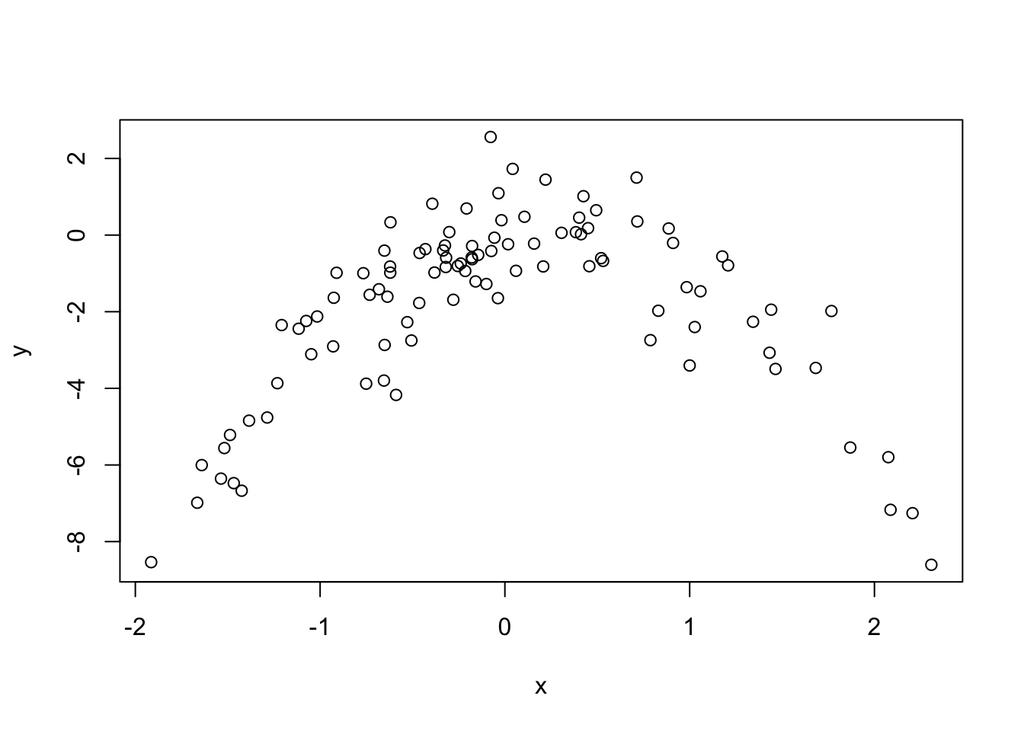

```r
plot(x, y)
```

Quadratic plot. X from about -2 to 2. Y from about -8 to 2.

**(c) Set a random seed, and then compute the LOOCV errors that result from fitting the following four models using least squares :**

1. $Y = \beta_0 + \beta_1X + \varepsilon$

```r
library(boot)
set.seed(1)
Data <- data.frame(x, y)
glm.fit.1 <- glm(y ~ x)
cv.glm(Data, glm.fit.1)$delta[1]
```

```
## [1] 5.890979
```

2. $Y = \beta_0 + \beta_1X + \beta_2X^2 + \varepsilon$

```r
glm.fit.2 <- glm(y ~ poly(x, 2))
cv.glm(Data, glm.fit.2)$delta[1]
```

```
## [1] 1.086596
```

3. $Y = \beta_0 + \beta_1X + \beta_2X^2 + \beta_3X^3 + \varepsilon$

```r
glm.fit.3 <- glm(y ~ poly(x, 3))
cv.glm(Data, glm.fit.3)$delta[1]
```

```
## [1] 1.102585
```

4. $Y = \beta_0 + \beta_1X + \beta_2X^2 + \beta_3X^3 + \beta_4X^4 + \varepsilon$

```r
glm.fit.4 <- glm(y ~ poly(x, 4))
cv.glm(Data, glm.fit.4)$delta[1]
```

```
## [1] 1.114772
```

**(d) Repeat (c) using another random seed, and report your results. Are your results the same as what you got in (c) ? Why ?**

```r
set.seed(10)
fit.glm.1 <- glm(y ~ x)
cv.glm(Data, fit.glm.1)$delta[1]
```

```
## [1] 5.890979
```

```r
fit.glm.2 <- glm(y ~ poly(x, 2))
cv.glm(Data, fit.glm.2)$delta[1]
```

```
## [1] 1.086596
```

```r
fit.glm.3 <- glm(y ~ poly(x, 3))
cv.glm(Data, fit.glm.3)$delta[1]
```

```
## [1] 1.102585
```

```r
fit.glm.4 <- glm(y ~ poly(x, 4))
cv.glm(Data, fit.glm.4)$delta[1]
```

```
## [1] 1.114772
```

The results above are identical to the results obtained in (c) since LOOCV evaluates $n$ folds of a single observation.

**(e) Which of the models in (c) had the smallest LOOCV error ? Is this what you expected ? Explain your answer.**

We may see that the LOOCV estimate for the test MSE is minimum for “glm.fit.2”, this is not surprising since we saw clearly in (b) that the relation between “x” and “y” is quadratic.

**(f) Comment on the statistical significance of the coefficient estimates that results from fitting each of the models in (c) using least squares. Do these results agree with the conclusions drawn based on the cross-validation results ?**

```r
summary(glm.fit.4)
```

```
##
## Call:
## glm(formula = y ~ poly(x, 4))
##
## Deviance Residuals:
##     Min       1Q   Median       3Q      Max
## -2.8914  -0.5244   0.0749   0.5932   2.7796
##
## Coefficients:
##             Estimate Std. Error t value Pr(>|t|)
## (Intercept)  -1.8277     0.1041 -17.549   <2e-16 ***
## poly(x, 4)1   2.3164     1.0415   2.224   0.0285 *
## poly(x, 4)2 -21.0586     1.0415 -20.220   <2e-16 ***
## poly(x, 4)3  -0.3048     1.0415  -0.293   0.7704
## poly(x, 4)4  -0.4926     1.0415  -0.473   0.6373
## ---
## Signif. codes:  0 '***' 0.001 '**' 0.01 '*' 0.05 '.' 0.1 ' ' 1
##
## (Dispersion parameter for gaussian family taken to be 1.084654)
##
##     Null deviance: 552.21  on 99  degrees of freedom
## Residual deviance: 103.04  on 95  degrees of freedom
## AIC: 298.78
##
## Number of Fisher Scoring iterations: 2
```

The p-values show that the linear and quadratic terms are statistically significants and that the cubic and 4th degree terms are not statistically significants. This agree strongly with our cross-validation results which were minimum for the quadratic model.

**Q9(a) We will now consider the “Boston” housing data set, from the “MASS” library. Provide an estimate for the population mean of “medv”. Call this estimate $\hat{\mu}$.**

```r
library(MASS)
attach(Boston)
mu.hat <- mean(medv)
mu.hat
```

```
## [1] 22.53281
```

**(b) Provide an estimate of the standard error of $\hat{\mu}$. Interpret this result.**

```r
se.hat <- sd(medv) / sqrt(dim(Boston)[1])
se.hat
```

```
## [1] 0.4088611
```

For a random sample from the population, we would expect sample mean of “medv” (mu.hat) to differ from population mean of “medv” by approximately 0.41, on average

**(c) Now estimate the standard error of $\hat{\mu}$ using the bootstrap. How does this compare to your answer from (b) ?**

```r
set.seed(1)
boot.fn <- function(data, index) {
    mu <- mean(data[index])
    return (mu)
}
bstrap = boot(medv, boot.fn, 1000)
bstrap
```

```
##
## ORDINARY NONPARAMETRIC BOOTSTRAP
##
##
## Call:
## boot(data = medv, statistic = boot.fn, R = 1000)
##
##
## Bootstrap Statistics :
##     original      bias    std. error
## t1* 22.53281 0.008517589   0.4119374
```

The bootstrap estimated standard error of $\hat{\mu}$ of 0.4119 is very close to the estimate found in (b) of 0.4089.

**(d) Based on your bootstrap estimate from (c), provide a 95% confidence interval for the mean of “medv”. Compare it to the results obtained using t.test(Boston$medv).**

```r
t.test(medv)
```

```
##
##  One Sample t-test
##
## data:  medv
## t = 55.111, df = 505, p-value < 2.2e-16
## alternative hypothesis: true mean is not equal to 0
## 95 percent confidence interval:
##  21.72953 23.33608
## sample estimates:
## mean of x
##  22.53281
```

```r
CI.mu.hat <- c(bstrap$t0 - 2 * 0.4119, bstrap$t0 + 2 * 0.4119)
CI.mu.hat
```

```
## [1] 21.70901 23.35661
```

The bootstrap confidence interval is very close to the one provided by the t.test() function.

**(e) Based on this data set, provide an estimate, $\hat{\mu}_{med}$, for the median value of “medv” in the population.**

```r
med.hat <- median(medv)
med.hat
```

```
## [1] 21.2
```

**(f) We now would like to estimate the standard error of $\hat{\mu}_{med}$. Unfortunately, there is no simple formula for computing the standard error of the median. Instead, estimate the standard error of the median using the bootstrap. Comment on your findings.**

```r
boot.fn <- function(data, index) {
    mu <- median(data[index])
    return (mu)
}
boot(medv, boot.fn, 1000)
```

```
##
## ORDINARY NONPARAMETRIC BOOTSTRAP
##
##
## Call:
## boot(data = medv, statistic = boot.fn, R = 1000)
##
##
## Bootstrap Statistics :
##     original  bias    std. error
## t1*     21.2 -0.0098   0.3874004
```

**(g) Based on this data set, provide an estimate for the tenth percentile of “medv” in Boston suburbs. Call this quantity $\hat{\mu}_{0.1}$.**

```r
medv.tenthperc = quantile(medv, c(0.1))
medv.tenthperc
```

```
##   10%
## 12.75
```

8. Use the bootstrap to estimate the standard error of $\hat{\mu}_{0.1}$. Comment on your findings.

```r
boot.fn <- function(data, index) {
    mu <- quantile(data[index], c(0.1))
    return (mu)
}
boot(medv, boot.fn, 1000)
```

```
##
## ORDINARY NONPARAMETRIC BOOTSTRAP
##
##
## Call:
## boot(data = medv, statistic = boot.fn, R = 1000)
##
##
## Bootstrap Statistics :
##     original  bias    std. error
## t1*    12.75 0.00515   0.5113487
```

Estimated Tenth-percentile of 12.75 with SE of 0.511. Small standard error relative to estimated tenth-percentile value.